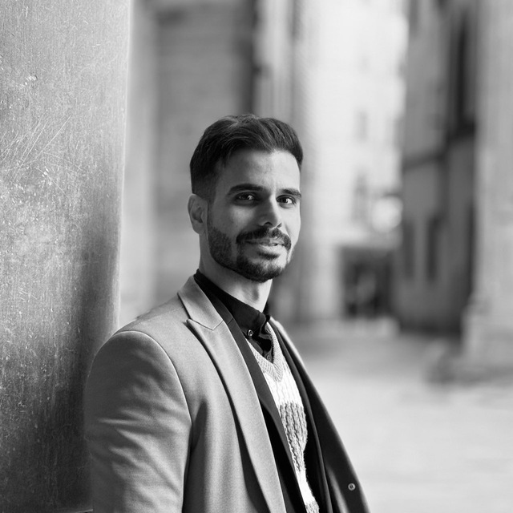

## Mohammad Khoshroo

Master Student at the University of Bologna

Field of Study: Statistical Science for Health and Population

Department: Statistical Sciences "Paolo Fortunati" - STAT

Welcome! My name is Mohammad Khoshroo

## Short bio

I am an experienced Data Analyst with over 4 years of expertise in healthcare and regulated settings, specializing in real-world evidence, clinical/PROMs data integration, and reproducible analytics. I am proficient in SQL, R (Shiny), Python, and Power BI, with a strong track record of automating pipelines, ensuring GCP-aligned data quality, and delivering actionable dashboards that improve decision-making and operational outcomes.

I am pursuing an MSc in Statistical Science for Health and Population Analytics at the University of Bologna, focusing on real-world evidence in digital health, specifically in the context of diabetes care.

Main Research Interests:

- Health Data Science and Biostatistics
- Predictive Modeling and Machine Learning
- Survival Analysis
- Real-Time Prediction of Time-Dependent Outcomes
- R and Python for Statistical Computing and Data Analysis
- Shiny Dashboards and Interactive Reporting
- Statistical Methods for Public Health
- Health Analytics in Digital Health

## MSc in Statistical Science for Health and Population Analytics

[University of Bologna](https://corsi.unibo.it/2cycle/StatisticalSciences) (October 2023 - Expected July 2026)

Notable Courses:

- [Advanced Survival Analysis](https://www.unibo.it/it/studiare/insegnamenti-competenze-trasversali-moocs/insegnamenti/insegnamento/2024/423554) by Rossella Miglio (Score: 28/30)
- [Methods and tools for Health Statistics](https://www.unibo.it/it/studiare/insegnamenti-competenze-trasversali-moocs/insegnamenti/insegnamento/2024/423907) by Fabrizio Carinci (Score: 26/30)

## BSc in Applied Statistics

[University of Tehran](https://ut.ac.ir/en) (September 2012 - January 2017)

Project: Predicting Economic Time Series Data Using ARIMA Model by Sodabeh Shemesavar (Score: 19/20)

Notable Courses:

- Time Series by Sodabeh Shemeh Savar (Score: 17/20)
- Statistical Programming by Behroz Kavei (Score: 19/20)
- Simulation by Sodabeh Shemesar (Score: 18/20)
- Data Mining with Hediyeh Sajedi
- Advanced Regression by Morteza Amini (Score: 16/20)

## Research Data Analyst

[AUSL Della Romagna](https://www.auslromagna.it/), Ravenna, Emilia-Romagna, Italy (Sep 2025 - Dec 2025)

- Contributed to a regional initiative to improve diabetes care through data-driven insights. Integrated and managed complex administrative, clinical, and PROMs datasets; conducted statistical analyses in R; co-authored scientific reports with a multidisciplinary team.
- Designed and built an interactive Shiny dashboard and R Markdown (knit) reports to visualize results, ensure reproducibility, and support stakeholder decision-making.

## Senior Data Analyst

[Orchid Pharmed Company](https://orchidpharmed.com), Tehran, Iran (Aug 2021 - Oct 2023)

- Developed interactive Power BI dashboards to visualize the progress of clinical trials and outcomes from multiple sources, including non-SQL databases.
- Built reusable ETL components, which cut projected clinical trial study time for data analysis by one week.
- Aggregated unstructured data from 10+ sources using R and Python scripts and Power BI for management reporting.
- Created automated systems that monitored and reported project statuses from eCRF and CRM sources to track changes in patient profiles after periodic monitoring, reducing errors in final reports.

## Data Analyst

- Developed dashboards for executive-level reporting using Power BI and SQL, pulling data from multiple sources such as eCRF, CRM, and Access apps to ensure patient health outcomes.
- Built machine learning models (decision trees, regression) to identify key attributes related to adverse event prevalence, helping in risk stratification.
- Automated monitoring and QC processes, reducing error rates by 50% and boosting reporting efficiency by 80%.

## Data Analyst

[BANKING INDUSTRY ANALYSIS MOGHADAM (MIBIA)](https://www.mibia.ir/), Tehran, Iran (Sep 2017 - Jun 2019)

- Managed, reviewed, and analyzed financial statements of banks. Provided recommendations for improving forecasting and modeling key metrics, which were adopted by Management (PCA).
- Identified steps that reduced error rates by 60%, resulting in significant cost and time savings.

## Shiny Dashboards for Health Courses

Developed two interactive Shiny dashboards as part of my coursework in Advanced Survival Analysis and Methods and Tools for Health. These dashboards visualize key metrics and help users explore data dynamically.

- [**Methods and Tools for Health Statistics Dashboard**](https://35x7b4-seyed0mohammad-khoshroo.shinyapps.io/Mortality-Risk-Dashboard/)

  This dashboard visualizes health data using statistical tools to help healthcare professionals make data-driven decisions. Built with hospital data on circulatory conditions in New York State, it features two main sections: Descriptive Analytics (providing insights on patient volume, mortality risk, diagnoses, and demographics) and Modeling & Machine Learning (with logistic regression and decision tree models to predict in-hospital mortality). The interactive, filterable features allow users to explore data by various factors. This app bridges statistical analysis and real-world healthcare applications, and I plan to develop it further into an R package for easy use and distribution.
- [**Advanced Survival Analysis Dashboard**](https://35x7b4-seyed0mohammad-khoshroo.shinyapps.io/Advanced-survival-dashboard/)

  This Shiny dashboard is designed to visualize survival analysis results, allowing users to interactively explore Kaplan-Meier curves, Cox Proportional Hazards models, and stratified survival data. It also includes advanced survival models such as AFT (Accelerated Failure Time), competing risks (using cIF, Cox, and Fine & Gray), and multi-state models. Users can dynamically select and deselect variables to observe real-time changes in interpretation, results, and plots. This tool is especially useful for students and researchers analyzing time-to-event data. The dashboard is not yet fully completed, and after finalizing it and coordinating with the relevant professor, I plan to organize a seminar for students. Additionally, I aim to develop this dashboard into an R package for easier use and distribution.

## Android Applications Development

In addition to my Shiny dashboard projects, I developed three mobile applications for Android. These applications were created to address different needs and provide useful tools for users.

- [**Stats App**](https://cafebazaar.ir/app/com.mohammad.statistics?l=en)

  Stats App is a statistical software designed for students, offering key features such as all major statistical distributions with their functions, mean, variance, and moment-generating functions. It allows users to calculate density or probability values, cumulative probabilities for Normal, t-Student, Fisher, and Chi-square distributions, and quantiles for the Normal distribution. The app also includes a statistical calculator for mean, variance, sums, and squared values, as well as a variety of derived formulas and integrals for advanced calculations.
- [**Doz(X O)**](https://cafebazaar.ir/app/com.mohammad.game_doz?l=en)

  This app taught me logical thinking and served as an exercise during my bachelor’s degree. It is a fun, engaging, and healthy game suitable for all ages, allowing 2, 3, or 4 players to play simultaneously. The game also provides the option to set the number of victories required to win.
- [**EstekhdamShuo**](https://cafebazaar.ir/app/com.mohammadsmk.examquestion2c?l=en)

  This app is designed for anyone preparing for exams, featuring a timer and multiple questions across various scientific fields. It provides scores and highlights correct and incorrect answers, helping users track their performance. The app includes a collection of recruitment questions for practice.

## Technical Skills

- Programming Languages: R, Python, SQL, SAS, Stata
- Data Visualization & Analysis:R shiny, Power BI, Microsoft Excel-VBA, Git
- Project Management Frameworks: Agile and Waterfall

## Pharma & Clinical Data

- Standards & Regulations: CDISC (Clinical Data Interchange Standards Consortium), GCP (Good Clinical Practice)

## Soft Skills

- Problem Solving
- Teamwork
- Communication
- Adaptability

## Languages

- Persian: Native
- English: Advanced
- Italian: Elementary

## Professional Association and Address

Health Data Science | Data Analyst

AUSL della Romagna

University Of Bologna

Bologna,Italy

## Contact

- Email: SeyedMohamm.khoshroo@studio.unibo.it

## Social Links

- Github: [Mohammad Khoshroo](https://github.com/MohammadSmk72)
- Linkedin: [Mohammad Khoshroo](https://www.linkedin.com/in/mohammad-khoshroo-545127167/)